# Part - 1

# 7.What is the oldest pet?

Pets age —> Sort —> Number —> Largest —> 167 that is Cat

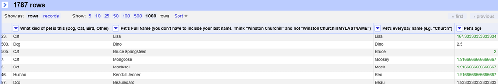

# 8.Which are more popular, betta fish or goldfish? How many of each?

Bettafish —> Facet —> Text facet —> count 2  
Goldfish —> Facet —> Text facet —> Count 7  
More popular fish is Goldfish

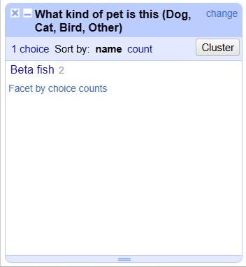

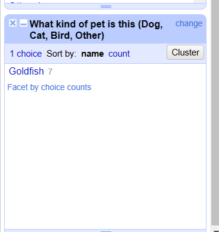

# 9.What’s the most popular everyday name for a cat?

Cat —> Pet’s everyday name —> Facet —> Text facet —> sort by count —> Kitty-7(count)

[figure not shown]

# 10.What’s the most popular full name for a dog?

Dog —> Pet’s Full Name —> Facet —> Text Facet —> Sort by count —> Sophie 10(count)

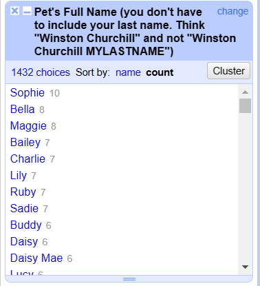